# AIC H1

Elena C

2024-01-10

## Load packages

```r
library(tidyverse)
```

```r
library(broom)
library(readxl)
library(AICcmodavg)
library(ggplot2)
```

## Load data and inspect it for typos

```r
h1_data <- read.csv("C:/Users/ecesnait/Desktop/EEGManyPipelines/Data/Big Analysis/all_var_AQ_h1.csv")
h1_data <- as.data.frame(h1_data)

# Software
h1_data$software[h1_data$software== 'eeglab_erplab'] <- 'eeglab'
h1_data$software[h1_data$software== 'eeglab_limo'] <- 'eeglab'
table(h1_data$software)
```

```
##
##        besa  brainstorm brainvision      custom      eeglab   fieldtrip
##           1           5          12           3          58          29
##   mnepython       other           R         spm
##          43          13           1           3
```

```r
#Fill in empty responses
# High-pass filter type & direction
h1_data$ans_hf_type[h1_data$ans_hf_type== ''] <- 'unknown'
h1_data$ans_hf_direction[h1_data$ans_hf_direction == ''] <- 'unknown'
table(h1_data$ans_hf_type)
```

```
##
##  hf_fir  hf_iir     IIR   other unknown
##      94      44       2       2      26
```

```r
table(h1_data$ans_hf_direction) # has almost mo variability - remove later
```

```
##
##     fwd fwd_bwd fwr_bwd fwr_bwr   other unknown
##      16      46       1       1       3     101
```

```r
# Segment exclusion criteria
h1_data$ans_exclusion_criteria_seg[h1_data$ans_exclusion_criteria_seg == ''] <- 'unknown'
table(h1_data$ans_exclusion_criteria_seg)
```

```
##
##  automatic mul_thresh      other     plugin     thresh    unknown     visual
##          3         38         16         24         34         12         41
```

```r
#Time window start, end & length
#exchange missing values to the mean of the column
h1_data$ans_time_w_start_h1[is.na(h1_data$ans_time_w_start_h1)] <- mean((h1_data$ans_time_w_start_h1), na.rm = T)
h1_data$ans_time_w_end_h1[is.na(h1_data$ans_time_w_end_h1)] <- mean((h1_data$ans_time_w_end_h1), na.rm = T)
h1_data$time_w_length_h1[is.na(h1_data$time_w_length_h1)] <- mean((h1_data$time_w_length_h1), na.rm = T)
#table(h1_data$ans_time_w_start_h1)

# ICA algorythm
h1_data$ans_ica_algo[h1_data$ans_ica_algo == ''] <- 'unknown'
table(h1_data$ans_ica_algo)
```

```
##
##      amica ex_infomax    fastICA    infomax      other     picard     runica
##          6         30         35         49          3         11          1
##    unknown
##         33
```

```r
#Baseline start and stop
h1_data$ans_baseline_start[h1_data$ans_baseline_start == '-200 ms'] <- '-200'
h1_data$ans_baseline_start[h1_data$ans_baseline_start == '-200ms'] <- '-200'
h1_data$ans_baseline_start <- as.numeric(h1_data$ans_baseline_start)
h1_data$ans_baseline_start[is.na(h1_data$ans_baseline_start)] <- mean((h1_data$ans_baseline_start), na.rm = T)
h1_data$ans_baseline_stop[is.na(h1_data$ans_baseline_stop)] <- mean((h1_data$ans_baseline_stop), na.rm = T)
```

## Prepare data for regression analysis

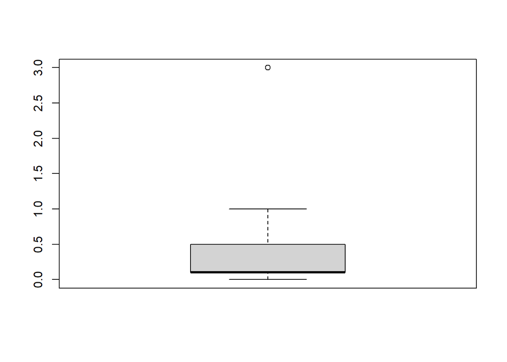

```r
# high collinearity problem removal
h1_data <- h1_data[-which(h1_data$mc_method_h1=='rft'),] # 3 teams removed

# too few samples that give Nan results in our models:
# ans_software_hostBESA Research 7.1  , ans_software_hostPython 3.8.10  , ans_hf_directionfwr_bwr, ans_ica_algoother
h1_data$ans_software_host[h1_data$ans_software_host == 'BESA Research 7.1'] <- 'unknown'
h1_data$ans_software_host[h1_data$ans_software_host == 'Python 3.8.10'] <- 'unknown'
h1_data$ans_software_host[h1_data$ans_software_host == 'R 4.1.3'] <- 'unknown'
h1_data$ans_hf_direction[h1_data$ans_hf_direction == 'fwr_bwr'] <- 'unknown'
h1_data$ans_ica_algo[h1_data$ans_ica_algo == 'other'] <- 'unknown'

# outliers removal
hf_out <- boxplot(h1_data$hf_cutoff)$out
```

```r
h1_data$hf_cutoff[which(h1_data$hf_cutoff == hf_out)] <- mean((h1_data$hf_cutoff), na.rm = T) # removed one team that had 3 for a  HP filter

# cut data into dependent and independent variables
dependent_h1 <- h1_data[,c(27,28)] # binary H1 outcome and pvalues
h1_data <- h1_data[,c(2:26)] #delete the row numbers and dependent variables

# look if there are any NaN values
which(is.na(h1_data),arr.ind=TRUE) # row 157 column 15 is NA (Q: if team corrected for multiple comparisons 1 and 0)
```

```
##     row col
## 160 157  15
```

```r
# Caution: remove them from the dataset
dependent_h1 <- dependent_h1[-157,]
h1_data <- h1_data[-157,]

# Select only numeric predictors
mynumericdata <- h1_data %>%
  dplyr::select_if(is.numeric)

shapiro.test(mynumericdata$hf_cutoff)#no data is normal
```

```
##
##  Shapiro-Wilk normality test
##
## data:  mynumericdata$hf_cutoff
## W = 0.74908, p-value = 1.931e-15
```

## Z-score p-values and normalize numeric data

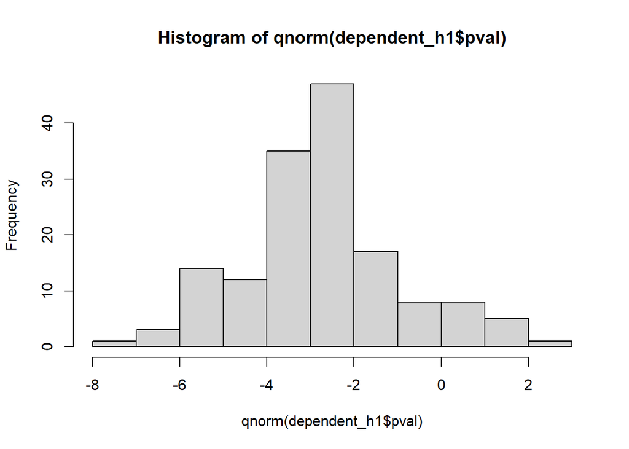

```r
hist(qnorm(dependent_h1$pval))
```

```r
pval_zscore <- qnorm(dependent_h1$pval)

indx_inf <- which(!is.finite(pval_zscore))
pval_zscore <- pval_zscore[-indx_inf] # remove the infinite value due to a mistakenly assigned 0 to pval it also takeS NAN values
h1_data <- h1_data[-indx_inf,] # remove those rows from independent variables too

continuous <- c(3, 7, 8, 10, 16:18, 23:25)

#normalizing data
for (i in 1:length(continuous)) {
  contin_data_col <- h1_data[,continuous[i]]
  h1_data[,continuous[i]] <- scale(contin_data_col)
}
```

## Build models

```r
#add pval
h1_data$pval <- pval_zscore

# models including full data and but no interactions
model_complete <- glm(pval ~ ., data = h1_data)

#summarize the model
summary(model_complete)
```

```
##
## Call:
## glm(formula = pval ~ ., data = h1_data)
##
## Deviance Residuals:
##     Min       1Q   Median       3Q      Max
## -2.9109  -0.3559   0.0000   0.4394   1.9177
##
## Coefficients:
##                                            Estimate Std. Error t value Pr(>|t|)
## (Intercept)                              -10.882451   5.184743  -2.099  0.04122
## softwarebrainstorm                        11.348032   4.212771   2.694  0.00977
## softwarebrainvision                        9.565599   4.130093   2.316  0.02497
## softwarecustom                             8.537405   3.557045   2.400  0.02040
## softwareeeglab                            11.359564   4.204268   2.702  0.00956
## softwarefieldtrip                         10.367960   4.149367   2.499  0.01602
## softwaremnepython                          8.645716   4.839929   1.786  0.08050
## softwareother                             11.183601   4.246259   2.634  0.01140
## softwareR                                  2.743655   2.619322   1.047  0.30024
## ans_software_hostBrain Vision Analyzer     0.985992   1.426157   0.691  0.49274
## ans_software_hostMATLAB                   -2.161271   2.235176  -0.967  0.33853
## ans_software_hostMATLAB R2015b             2.281429   2.038374   1.119  0.26873
## ans_software_hostMATLAB R2016b             0.657309   1.846455   0.356  0.72345
## ans_software_hostMATLAB R2017b            -0.464206   2.151939  -0.216  0.83014
## ans_software_hostMATLAB R2018a             3.117886   2.885148   1.081  0.28536
## ans_software_hostMATLAB R2018b             2.513732   1.843202   1.364  0.17913
## ans_software_hostMATLAB R2019a            -0.669827   1.673809  -0.400  0.69084
## ans_software_hostMATLAB R2019b            -1.632757   1.839561  -0.888  0.37929
## ans_software_hostMATLAB R2020a            -1.357371   1.694514  -0.801  0.42714
## ans_software_hostMATLAB R2020b            -1.324411   1.585398  -0.835  0.40773
## ans_software_hostMATLAB R2021a            -0.218358   1.425112  -0.153  0.87888
## ans_software_hostMATLAB R2021b            -2.293079   1.515051  -1.514  0.13684
## ans_software_hostMATLAB R2022a            -1.437891   1.795226  -0.801  0.42719
## ans_software_hostPython 3.10.4             2.989361   4.100679   0.729  0.46962
## ans_software_hostPython 3.11               1.731824   4.520166   0.383  0.70335
## ans_software_hostPython 3.6                2.991004   3.538446   0.845  0.40223
## ans_software_hostPython 3.6.9              0.320541   4.309363   0.074  0.94102
## ans_software_hostPython 3.7               -0.497920   4.518055  -0.110  0.91271
## ans_software_hostPython 3.7.10             6.518352   4.818406   1.353  0.18259
## ans_software_hostPython 3.8                0.812160   4.056589   0.200  0.84218
```

[output cut: 174 more lines]

```
## ans_bad_comp_sel_visual                  *
## ans_bad_comp_sel_plugin
## ans_baseline_start                       .
## ans_baseline_stop
## bs_window_length
## ---
## Signif. codes:  0 '***' 0.001 '**' 0.01 '*' 0.05 '.' 0.1 ' ' 1
##
## (Dispersion parameter for gaussian family taken to be 2.1198)
##
##     Null deviance: 462.712  on 150  degrees of freedom
## Residual deviance:  99.631  on  47  degrees of freedom
## AIC: 575.73
##
## Number of Fisher Scoring iterations: 2
```

```r
#Software
test_soft <- h1_data
test_soft$software <- as.factor(test_soft$software)
test_soft <- within(test_soft, software <- relevel(software, ref = 'eeglab'))
model_soft <- glm(pval ~ software, data = test_soft)
summary(model_soft)
```

```
##
## Call:
## glm(formula = pval ~ software, data = test_soft)
##
## Deviance Residuals:
##     Min       1Q   Median       3Q      Max
## -5.3104  -0.9151  -0.0351   0.8406   4.7837
##
## Coefficients:
##                     Estimate Std. Error t value Pr(>|t|)
## (Intercept)         -2.53257    0.24619 -10.287   <2e-16 ***
## softwarebesa        -0.55767    1.79227  -0.311    0.756
## softwarebrainstorm   0.71828    0.83122   0.864    0.389
## softwarebrainvision -0.26022    0.56855  -0.458    0.648
## softwarecustom       0.99917    1.05411   0.948    0.345
## softwarefieldtrip   -0.52256    0.42641  -1.225    0.222
## softwaremnepython   -0.04355    0.37606  -0.116    0.908
## softwareother       -0.16398    0.56855  -0.288    0.773
## softwareR           -1.63639    1.79227  -0.913    0.363
## ---
## Signif. codes:  0 '***' 0.001 '**' 0.01 '*' 0.05 '.' 0.1 ' ' 1
##
## (Dispersion parameter for gaussian family taken to be 3.151628)
##
##     Null deviance: 462.71  on 150  degrees of freedom
## Residual deviance: 447.53  on 142  degrees of freedom
## AIC: 612.58
##
## Number of Fisher Scoring iterations: 2
```

```r
# Build reduced models including one predictor

models_list_single_1 = list()
for (g in 1:ncol(h1_data[,-1])){
  reduced_1 = glm(pval ~ h1_data[,g], data = h1_data)
  models_list_single_1 = append(models_list_single_1, list(reduced_1))
}
```

## Compare models using AIC

Interpretation:

**K:** The number of parameters in the model. The default K is 2, so a model with one parameter will have a K of 2 + 1 = 3.

**AICc:** The information score of the model (the lower-case ‘c’ indicates that the value has been calculated from the AIC test corrected for small sample sizes). The smaller the AIC value, the better the model fit.

**Delta_AICc:** The difference in AIC score between the best model and the model being compared: In our data it looks like the first two models are equally good (model 15 and 23).

**AICcWt:** AICc weight, which is the proportion of the total amount of predictive power provided by the full set of models contained in the model being assessed. In this case, the top model contains 23% of the total explanation that can be found in the full set of models.

**Cum.Wt:** The sum of the AICc weights. The cumulative AICc weight is 0.46, meaning 46% of the support in the data are for these two models.

```r
#Put all models into the list:
models_list_full2 <- c(models_list_single_1, list(model_complete))

# Run AIC
aictab(cand.set = models_list_full2)
```

```
##
## Model selection based on AICc:
##
##         K    AICc Delta_AICc AICcWt Cum.Wt      LL
## Mod15   3  596.82       0.00   0.23   0.23 -295.33
## Mod23   3  596.84       0.02   0.23   0.46 -295.34
## Mod6    6  597.79       0.97   0.14   0.60 -292.60
## Mod9   13  598.05       1.23   0.13   0.73 -284.70
## Mod10   3  599.11       2.29   0.07   0.80 -296.47
## Mod12   8  599.98       3.16   0.05   0.85 -291.48
## Mod17   3  601.25       4.43   0.03   0.88 -297.54
## Mod25   3  601.94       5.12   0.02   0.89 -297.89
## Mod21   3  602.46       5.64   0.01   0.91 -298.15
## Mod24   3  602.55       5.73   0.01   0.92 -298.19
## Mod18   3  602.60       5.78   0.01   0.93 -298.22
## Mod14   3  603.05       6.23   0.01   0.95 -298.44
## Mod8    3  603.54       6.72   0.01   0.95 -298.69
## Mod19   3  603.62       6.80   0.01   0.96 -298.73
## Mod7    3  603.62       6.80   0.01   0.97 -298.73
## Mod3    3  603.69       6.87   0.01   0.98 -298.76
## Mod22   3  603.75       6.93   0.01   0.98 -298.80
## Mod16   3  603.77       6.95   0.01   0.99 -298.81
## Mod20   8  604.52       7.69   0.00   1.00 -293.75
## Mod11   8  606.20       9.38   0.00   1.00 -294.59
## Mod4    6  607.30      10.48   0.00   1.00 -297.36
## Mod13   7  608.74      11.92   0.00   1.00 -296.98
## Mod5    6  609.44      12.62   0.00   1.00 -298.43
## Mod1   10  614.15      17.33   0.00   1.00 -296.29
## Mod2   36  654.04      57.22   0.00   1.00 -279.34
## Mod26 105 1070.40     473.58   0.00   1.00 -182.87
```

## Fit the best model acording to ACI

# Multiple comparissons (80 teams corrected for multiple comparissons, and 87 did not)

```r
model_mt <- glm(pval ~ ans_mt_h1, data = h1_data)
summary(model_mt)
```

```
##
## Call:
## glm(formula = pval ~ ans_mt_h1, data = h1_data)
##
## Deviance Residuals:
##     Min       1Q   Median       3Q      Max
## -5.5592  -0.8064  -0.0425   0.9895   4.5349
##
## Coefficients:
##             Estimate Std. Error t value Pr(>|t|)
## (Intercept)  -2.2838     0.1938  -11.79  < 2e-16 ***
## ans_mt_h1    -0.7436     0.2806   -2.65  0.00891 **
## ---
## Signif. codes:  0 '***' 0.001 '**' 0.01 '*' 0.05 '.' 0.1 ' ' 1
##
## (Dispersion parameter for gaussian family taken to be 2.965651)
##
##     Null deviance: 462.71  on 150  degrees of freedom
## Residual deviance: 441.88  on 149  degrees of freedom
## AIC: 596.66
##
## Number of Fisher Scoring iterations: 2
```

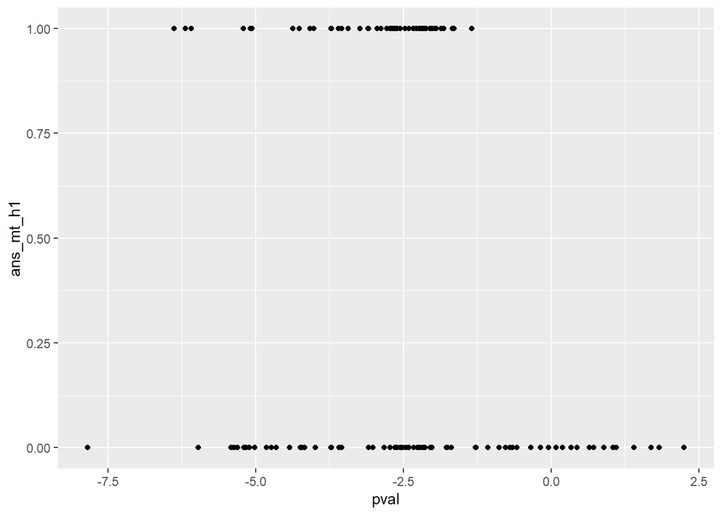

```r
#Scatterplot
ggplot(h1_data, aes(x=pval, y=ans_mt_h1)) +
  geom_point()
```

# Baseline start

```r
model_bs <- glm(pval ~ ans_baseline_start, data = h1_data)
summary(model_bs)
```

```
##
## Call:
## glm(formula = pval ~ ans_baseline_start, data = h1_data)
##
## Deviance Residuals:
##     Min       1Q   Median       3Q      Max
## -5.0817  -0.9470   0.0373   0.7767   5.0124
##
## Coefficients:
##                    Estimate Std. Error t value Pr(>|t|)
## (Intercept)         -2.6384     0.1402 -18.825  < 2e-16 ***
## ans_baseline_start  -0.3721     0.1406  -2.646  0.00902 **
## ---
## Signif. codes:  0 '***' 0.001 '**' 0.01 '*' 0.05 '.' 0.1 ' ' 1
##
## (Dispersion parameter for gaussian family taken to be 2.966068)
##
##     Null deviance: 462.71  on 150  degrees of freedom
## Residual deviance: 441.94  on 149  degrees of freedom
## AIC: 596.68
##
## Number of Fisher Scoring iterations: 2
```

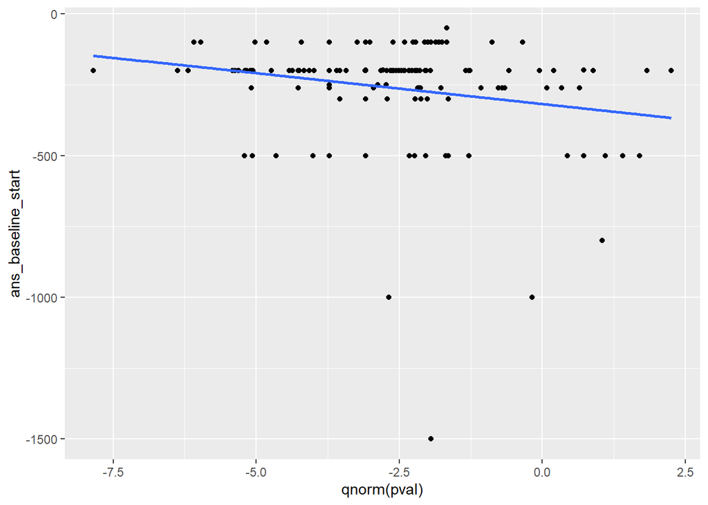

```r
#Scatterplot without scaling
h1_data <- read.csv("C:/Users/ecesnait/Desktop/EEGManyPipelines/Data/Big Analysis/all_var_AQ_h1.csv")
h1_data <- as.data.frame(h1_data)
#Baseline start and stop
h1_data$ans_baseline_start[h1_data$ans_baseline_start == '-200 ms'] <- '-200'
h1_data$ans_baseline_start[h1_data$ans_baseline_start == '-200ms'] <- '-200'
h1_data$ans_baseline_start <- as.numeric(h1_data$ans_baseline_start)
h1_data$ans_baseline_start[is.na(h1_data$ans_baseline_start)] <- mean((h1_data$ans_baseline_start), na.rm = T)
h1_data$ans_baseline_stop[is.na(h1_data$ans_baseline_stop)] <- mean((h1_data$ans_baseline_stop), na.rm = T)

ggplot(h1_data, aes(x=qnorm(pval), y=ans_baseline_start)) +
  geom_point() +
  geom_smooth(method=lm, se=FALSE)
```